# CB5T × 計算論

## 国里愛彦（くにさと よしひこ）

国里愛彦

- 専修大学人間科学部心理学科 教授
- 専門：計算論的精神医学、認知行動療法
- COI開示：発表に関連し、開示すべきCOI関係にある企業などはありません。

## 静的記述から動的メカニズムへ

- “パーソナリティは、個人の内部で、**環境への特有な適応を決定するような、精神物理学的体系の力動的機構**である” (Allport 1937)
- ビッグ・ファイブモデルはオルポートの定義のパーソナリティを扱えている？
- CB5Tは、**パーソナリティを目標へ向けて自己調整するサイバネティック・システム**と捉え、**ビッグ・ファイブ特性は目標追求の共通メカニズムにおける個人差**と説明する (DeYoung 2015)

## 特性と特徴的適応

|  | 特性 | 特徴的適応 |
| --- | --- | --- |
| 説明 | 目標追求の共通メカニズムにおける感度や作動強度の個人差 | 経験を通して形成される、状況に応じた目標・解釈・方略 |
| 例 | ビッグ・ファイブ特性の神経症傾向 | 社交場面での失敗経験から、「不安に見られてはいけない」という目標を設定し、かえって自己注目と苦痛が高まる。 |

> 特性が同じでも、学習した目標・解釈・方略（特徴的適応）が違えば行動は変わる (DeYoung 2015; DeYoung and Weisberg 2018)

## ビッグ・ファイブとサイバネティック機能

| ビッグ・ファイブ | 主なサイバネティック機能 |
| --- | --- |
| **神経症傾向** | 不確実性・脅威・罰への防御 |
| **外向性** | 行動的探索と報酬への接近 |
| **経験への開放性** | 情報の認知的・知覚的探索 |
| **誠実性** | 長期目標の維持 |
| **協調性** | 他者との目標調整 |

- ビッグ・ツーの**安定性(Stability)**は維持、**可塑性(Plasticity)**は更新を担う (DeYoung, Quilty, and Peterson 2007; DeYoung 2015)

## 心理的エントロピー

$$\boxed{
\text{目標} \rightarrow \text{方略の選択} \rightarrow \text{行動} \rightarrow
\text{結果の解釈} \rightarrow \text{目標との比較} \circlearrowleft
}$$

- 結果が目標や予測から外れると、制御すべき**誤差**が生じる
- **心理的エントロピー＝不確実性や葛藤が高まり現在の目標追求が揺らぐ状態**(目標・世界の解釈・方略のどこが問題なのか分からない状態)

> **心理的エントロピーと同一ではない**が、自由エネルギー原理は、CB5Tを数理的に記述する有力な候補 (Safron and DeYoung 2021; Safron and Sheikhbahaee 2023)

## 自由エネルギー原理(free-energy principle)

- 自由エネルギー原理は Friston (2010) による**脳と心の統一的理論**
- 直接観測できない外部状態 $s^*$ を感覚入力$o$から推測するベイズ推論モデル($p(s|o) = \frac{p(o|s)p(s)}{p(o)}$)の一種
- **知覚・行動・学習を「自由エネルギーの最小化」という一つの原理で統一的に説明**しようとする

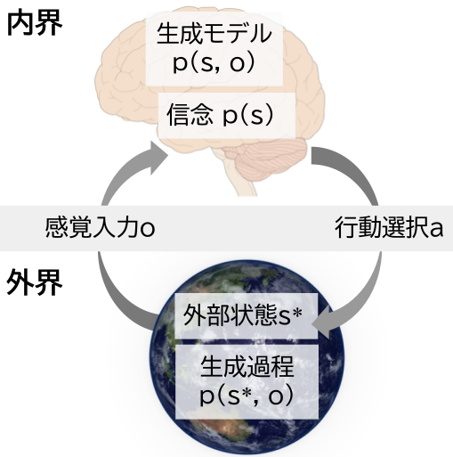

## サプライザルと変分自由エネルギー$\textbf{F}$

- 感覚入力$o$の得られにくさである**サプライザル**($-\ln p(o)$)が小さいほど、モデルの予測性能が良いが、その計算は困難/不可能
- **近似事後分布** ($q(s)$) を導入し、サプライザルの上界となる**変分自由エネルギー ($F$) の最小化**で、真の事後分布 $p(s\mid o)$ に近づける。

→**変分法による近似ベイズ推論**

$$p(s|o) = \frac{p(o|s)p(s)}{p(o)}$$

$$F = \int q(s)\ln \frac{q(s)}{p(s,o)}ds$$

## 期待自由エネルギー$\textbf{G}$

- 行動選択には、未来に生じることを考慮する必要があり、$F$ではなく**期待自由エネルギー$G$**を計算する。$G$が小さい方策ほど選ばれやすく、結果として$G$の最小化を達成する（**能動的推論**）

$$\begin{aligned}
G(\pi) = - \mathbb{E}_{q(\widetilde{s},\widetilde{o}|\pi)}[D_{KL}[q(\widetilde{s}|\widetilde{o},\pi) \,\Vert\, q(\widetilde{s}|\pi)]] - \mathbb{E}_{q(\widetilde{o}|\pi)}[\ln p(\widetilde{o}|C)]
\end{aligned}$$

- 第１項は新しい情報を求める**認識的価値**、第２項は選好$C$を含んでおり、好ましい観測を求める**実利的価値**。両価値のバランスをとりつつ行動は選択される。

## 自由エネルギーを下げる方法(Buckley et al. 2017)

- **知覚**：階層的神経回路で予測し、予測誤差から信念$q(s)$を更新する(予測誤差最小化)
- **行動**：外界に働きかけて感覚入力$o$を変えて、感覚入力を予測に合わせる
- **学習**：生成モデルのパラメータを更新する(知覚とくらべてゆっくりとした変化)

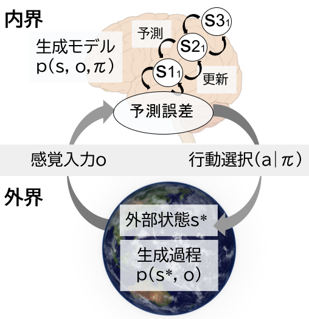

## POMDP（部分観測マルコフ決定過程）でモデル化

- **POMDP**は、外界の状態を直接観測できない状況で、得られた観測から状態を推論しながら行動する枠組み。
- 能動的推論では、POMDPをエージェントがもつ**世界の生成モデル**として用いる
- 因子グラフで表現し、状態$s$、観測$o$などの**変数を円**で、状態と観測、現在と次の状態など、**変数間の確率的な関係は四角**で表す

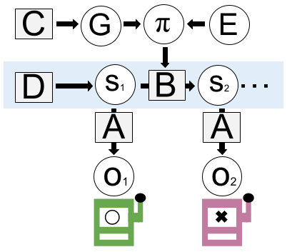

## 能動的推論モデルの作り方

- **s**:状態、**$\pi$**: 方策
- **A**:状態から観測の生成確率(**尤度**)
- **B**:**状態遷移確率**
- **C**:観測に対する**選好**
- **D**:試行開始時の**状態の事前分布**
- **E**：**方策の事前分布**（オプション）

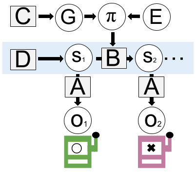

> ABCDを設定すれば能動的推論モデルが動き、行動の生成ができる。

## Barlowの神経症傾向

- Barlowによると、神経症傾向は**ストレス下の強い否定的感情**と**制御・対処できないという感覚**を含む (Barlow et al. 2014)。
- 感情障害は、気質的脆弱性、感情の嫌悪的解釈、回避の機能的な連鎖として理解できる (Bullis et al. 2019)。

|  | CB5Tでの整理 |
| --- | --- |
| **気質的脆弱性** | 防御系の感度が高く脅威に過敏な**特性** |
| **嫌悪的な解釈** | 脅威の過大視などの学習された**解釈** |
| **回避・安全行動** | 学習された回避的**方略や習慣** |

## トイモデルからはじめる

- Barlowの神経症傾向をCB5Tで整理した上で、能動的推論モデルのパラメータを設定する

| パタメータ | 神経症傾向が高い場合 |
| --- | --- |
| **A：尤度** | 悪い情報を信頼しやすい |
| **B：状態遷移** | 脅威は持続し、接近しても変えにくい |
| **C：選好** | 苦痛や失敗を強く避ける |
| **D：初期信念** | 開始時に脅威を高く見積もる |
| **E：方策事前分布** | 回避を選びやすい |

## シミュレーションの環境設定

- **回避は短期的には感情を弱めるが、長期的には対処可能性の学習を妨げる** (Bullis et al. 2019; Barlow et al. 2020)。

$$\boxed{
\text{回避} \rightarrow \text{短期的に不安(減)} \rightarrow
\text{修正情報(減)} \rightarrow \text{脅威信念の維持}
}$$

> 環境が安全か脅威か推測させる状況を用意し、環境の制御可能性を低めると回避が増えるか？  
> その後に環境の制御可能性が回復しても回避したままか？

## シミュレーションの環境設定

| 試行 | 外部環境 | 接近による脅威の解消 |
| --- | --- | --- |
| 1–50 | **制御可能** | 80% |
| 51–100 | **制御不能** | 10% |
| 101–150 | **回復** | 再び80% |

- **接近**：苦痛や失敗の可能性はあるが、状態を識別し目標を進められる
- **待機**：得られる情報が少なく、目標も進みにくい
- **回避**：短期的安堵を得やすいが、手がかりは曖昧で目標は進まない
- 神経症傾向の高低で各40エージェント作った平均をプロットする

## 高神経症傾向と回避

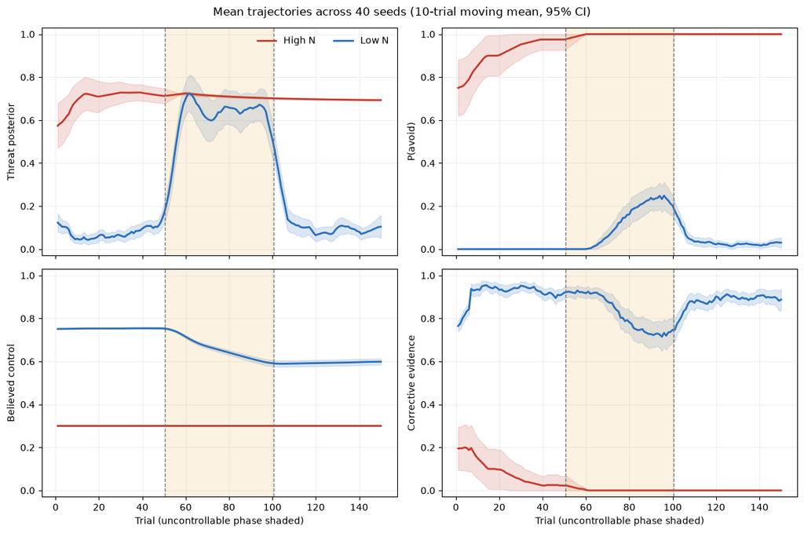

高神経症傾向(赤)では、**制御可能性が回復しても脅威信念が高く**(左上)、**早期から回避が多い**(右上)。回避は**接近による修正情報を遮断**(右下)

## 高神経症傾向の要素と組み合わせ

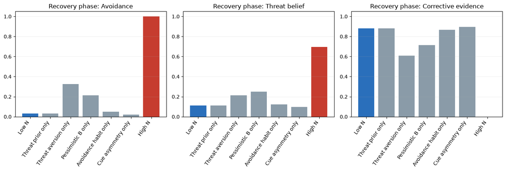

回復期の回避や脅威信念は、**脅威への嫌悪(C)**や**脅威が続く信念(B)**だけでも増加するが、複数の要因を組み合わせたものは、回避と脅威信念が最も強く、修正情報がほぼ得られない

## ポテンシャル・ランドスケープ(縮約力学モデル)

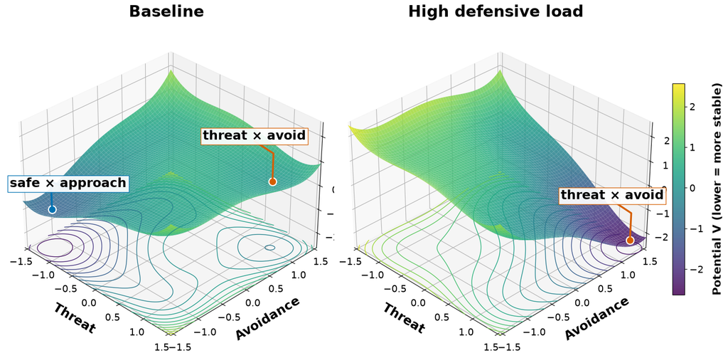

通常時は**安全・接近と脅威・回避の２つの谷がある**が(左)、防御負荷(神経症傾向、ストレスなど)が高まると**脅威・回避の谷に吸い込まれる**(右)

## まとめと今後の展開

- CB5Tは能動的推論と相性がよく、理論駆動型の柔軟なモデル化を提供してくれる（特性と特徴的適応から個人差を考慮した認知行動モデルを形式モデル化できる）。
- トイモデルだが、統一プロトコルの背景である神経症傾向の能動的推論モデル化ができた。モデルを発展させることで、統一プロトコルの作用機序の検討にも使えるかもしれない。
- まだ単純なトイモデルであり、神経症傾向以外の特性のモデル化、特徴的適応などの学習プロセスの検討、厳密な力学系モデルの検討など未解決の問題は多い（楽しい!!!）

## 引用文献

Allport, Gordon W. 1937. *Personality: A Psychological Interpretation*. New York: Henry Holt; Company.

Barlow, David H., Kristen K. Ellard, Shannon Sauer-Zavala, Jacqueline R. Bullis, and James R. Carl. 2014. “The Origins of Neuroticism.” *Perspectives on Psychological Science* 9 (5): 481–96. https://doi.org/10.1177/1745691614544528.

Barlow, David H., Brittany A. Harris, Erin H. Eustis, and Todd J. Farchione. 2020. “The Unified Protocol for Transdiagnostic Treatment of Emotional Disorders.” *World Psychiatry* 19 (2): 245–46. https://doi.org/10.1002/wps.20748.

Buckley, Christopher L, Chang Sub Kim, Simon McGregor, and Anil K Seth. 2017. “The Free Energy Principle for Action and Perception: A Mathematical Review.” *Journal of Mathematical Psychology* 81 (December): 55–79.

Bullis, Jacqueline R., Hannah Boettcher, Shannon Sauer-Zavala, Todd J. Farchione, and David H. Barlow. 2019. “What Is an Emotional Disorder? A Transdiagnostic Mechanistic Definition with Implications for Assessment, Treatment, and Prevention.” *Clinical Psychology: Science and Practice* 26 (2): e12278. https://doi.org/10.1111/cpsp.12278.

DeYoung, Colin G. 2015. “Cybernetic Big Five Theory.” *Journal of Research in Personality* 56 (June): 33–58.

DeYoung, Colin G, Lena C Quilty, and Jordan B Peterson. 2007. “Between Facets and Domains: 10 Aspects of the Big Five.” *Journal of Personality and Social Psychology* 93 (5): 880–96. https://doi.org/10.1037/0022-3514.93.5.880.

DeYoung, Colin G, and Yanna J Weisberg. 2018. “Cybernetic Approaches to Personality and Social Behavior.” In *The Oxford Handbook of Personality and Social Psychology*, 2nd ed. Oxford University Press. https://doi.org/10.1093/oxfordhb/9780190224837.013.25.

Friston, Karl. 2010. “The Free-Energy Principle: A Unified Brain Theory?” *Nature Reviews. Neuroscience* 11 (2): 127–38.

Safron, Adam, and Colin G DeYoung. 2021. “Integrating Cybernetic Big Five Theory with the Free Energy Principle: A New Strategy for Modeling Personalities as Complex Systems.” In *Measuring and Modeling Persons and Situations*, 617–49. Academic Press. https://doi.org/10.1016/B978-0-12-819200-9.00010-7.

Safron, Adam, and Zahra Sheikhbahaee. 2023. “Towards Understanding Persons and Their Personalities with Cybernetic Big Five Theory and the Free Energy Principle and Active Inference Framework.” In *Active Inference*, 105–25. Springer. https://doi.org/10.1007/978-3-031-47958-8_6.